# Population genetics analysis of_Melampsora larici-populina_ based on microsatellite markers

Ammar Abdalrahem

2025-02-23

## Introduction

The following automated workflow presents the population genetics analysis of Mlp using SSR marker data. This analysis includes genetic diversity and temporal and spatial analysis to define and compare sexual and asexual lineages. The workflow is divided into several steps, including data import, MLG and MLL definition, cluster identification, population genetic indices calculation, reproduction mode assignment based on genetic indices, and MLL persistence. The workflow is designed to be reproducible. The data used in this analysis is from the study “Long-lasting coexistence of multiple asexual lineages alongside their sexual counterparts in a fungal plant pathogen.” by Abdalrahem et al. (2025).

### Data retrieval

To begin the analysis, we will import the data from the Excel file. The data contains information about the population, year, and genotypes of Mlp isolates. We will filter out any isolates with unknown populations and convert the data into a data frame for further analysis.The data is available in the file “SexAsex4Ammar_240730.xlsx”.

```r
head(general_data)
```

```
##   Isolate Year  Pop Actu240729              Site Dept Dept #
## 1  14AA01 2014 14AA        old Cavalaire-sur-mer  Var     83
## 2  14AA04 2014 14AA        old Cavalaire-sur-mer  Var     83
## 3  14AA02 2014 14AA        old Cavalaire-sur-mer  Var     83
## 4  14AA05 2014 14AA        old Cavalaire-sur-mer  Var     83
## 5  14AA06 2014 14AA        old Cavalaire-sur-mer  Var     83
## 6  14AA10 2014 14AA        old Cavalaire-sur-mer  Var     83
##                       Region          Host Long   Lat Project ArchiveGM
## 1 Provence-Alpes-Côte d'Azur Populus nigra 6.53 43.17   Coll°         -
## 2 Provence-Alpes-Côte d'Azur Populus nigra 6.53 43.17   Coll°         -
## 3 Provence-Alpes-Côte d'Azur Populus nigra 6.53 43.17   Coll°         -
## 4 Provence-Alpes-Côte d'Azur Populus nigra 6.53 43.17   Coll°         -
## 5 Provence-Alpes-Côte d'Azur Populus nigra 6.53 43.17   Coll°         -
## 6 Provence-Alpes-Côte d'Azur Populus nigra 6.53 43.17   Coll°         -
##   Chromato_File Reader Vir Profil Data Conta Mqt Mlg Mll Mlp_91 Mlp_83 Mlp_50
```

[output cut: 20 more lines]

## The definition of MLLs

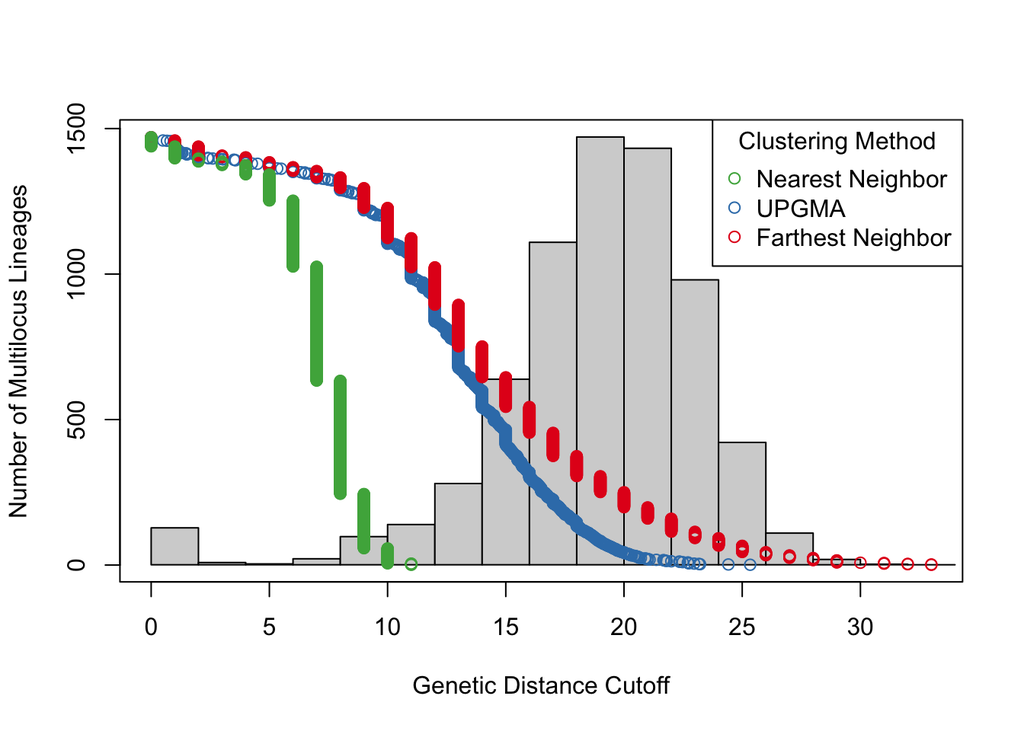

```r
# Create table of genotype data by select columns with "Mlp" in the name and the first column as isolate id
genotype_cols <- c("Isolate", grep("Mlp", names(general_data), value = TRUE))
genotype_data <- general_data[, genotype_cols] #

# Make isolate id as column names
rownames(genotype_data) <- genotype_data[,1]
# delete the first column not needed anymore
genotype_data$Isolate = NULL


# Convert data to genind object
data_GenInd <- df2genind(
  X = genotype_data,   # data.frame containing allele data
  sep = NULL,
  ncode = 3,           # the number of characters used for coding one genotype at one locus.
  ind.names = rownames(genotype_data),  # individuals names
  loc.names = colnames(genotype_data),  # markers names
  pop = general_data$Pop,               # giving the population of each individual
  NA.char = "999",                      # string corresponding to missing allele 999 or 999999
  ploidy = 2,
  type = "codom",                       #codom' stands for 'codominant' (e.g. microstallites)
  strata = NULL,
  hierarchy = NULL,
  check.ploidy = getOption("adegenet.check.ploidy") # check the ploidy of the data if it is correct
)

# Convert data to genclone object
data_Genclone <- as.genclone(data_GenInd)

# Define MLG according threshold = 0
# Means that two individuals are considered to be from the same MLG if their genetic distance is 0
# The "asis" option is used to indicate that missing data should be treated "as is," meaning that missing values will be retained as NA in the distance matrix.
mlg_assignments <- mlg.filter(data_Genclone, threshold = 0, distance = "diss.dist", threads = 1L,missing = "asis")


#add MLG result to the table
genotype_data$MLG <- mlg_assignments

#Define the MLL
#choose a threshold to represent the minimum genetic distance
#grouping individuals into the same MLL

data_filtered <-filter_stats(data_Genclone, distance = diss.dist, plot = TRUE, missing = "asis",hist= "sturges")
```

```r
#Define the MLL threshold
#According to the first gap on the Genetic Distance Cutoff plot
#The threshold is set to 5 to represent the minimum genetic distance for grouping individuals into the same MLL

mll_assignments<- mlg.filter(data_Genclone, threshold = 5 , algorithm = "average_neighbor" , distance = "diss.dist", threads = 1L, missing = "asis" )

genotype_data$MLL <- mll_assignments


#write.csv2(genotype_data, "data_new.csv")
```

### Ascending order for fixation of MLL

The idea to sort the MLLs in ascending order is to fix the order of the MLLs in the dataset. This will help in further analysis and visualization of the data. The MLLs are sorted based on the frequency of their occurrence in the dataset. The MLL with the highest frequency is assigned as 1 etc. The sorted MLLs are then added to the genotype data table as a new column called “organised_MLL”.

```r
# Calculate the frequency of each MLL combination
count_MLL_table <- data.frame(MLL = unique(genotype_data$MLL), Count = NA)

# for each MLL value, count the number of occurrences in the genotype data
# then store the count in the "Count" column of the count_MLL_table
for (i in 1:nrow(count_MLL_table)) {
  mll_value <- count_MLL_table$MLL[i]
  count_MLL_table$Count[i] <- sum(genotype_data$MLL == mll_value)
}

# Sort the dataframe in descending order by the "Count" column
count_MLL_table <- count_MLL_table[order(-count_MLL_table$Count), ]

# Create a new column "N" with values in ascending order
count_MLL_table$N <- 1:nrow(count_MLL_table)

# Add row names to count_MLL_table
rownames(count_MLL_table) <- NULL

# Create a temporary column with row names for genotype_data
genotype_data$temp_row_names <- rownames(genotype_data)

# Merge the "count_MLL_table" dataframe with the original "genotype_data" dataframe
genotype_data <- merge(genotype_data, count_MLL_table, by = "MLL", all.x = TRUE)

# Restore the original row names
rownames(genotype_data) <- genotype_data$temp_row_names

# Remove the temporary column
genotype_data$temp_row_names <- NULL
#genotype_data$MLL <- NULL

# Rename the "N" column to "organised_MLL"
colnames(genotype_data)[colnames(genotype_data) == "N"] <- "organised_MLL"


# Ascending order
genotype_data <- genotype_data[order(genotype_data$organised_MLL),]


#save the result
#write.xlsx(genotype_data,"new_genotype_data.xlsx", rowNames = TRUE)
```

## Clustering approch

### Assignment of isolates to clusters based on genetic data

Since our goal to define the reproductive mode of the population, we will assign the isolates to clusters based on their genetic data. We will use the Discriminant Analysis of Principal Components (DAPC) method to assign the isolates to clusters. The DAPC method is used to identify clusters in genetic data and assign individuals to these clusters based on their genetic profiles.

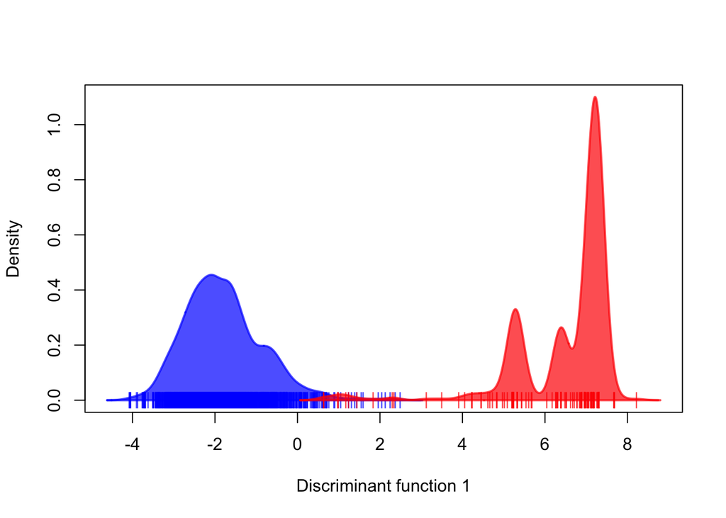

```r
# create a table of genotypes for allele data only
# Select columns with "Mlp" in the name and the first column as isolate id
genotype_cols <- c(grep("Mlp", names(genotype_data), value = TRUE))
genotype_mlp <- genotype_data[, genotype_cols]

#make isolate id as column names
rownames(genotype_mlp) <- rownames(genotype_data)

# Convert data to genind object
data_GenInd <- df2genind(
  X = genotype_mlp,   # data.frame containing allele data
  sep = NULL,
  ncode = 3,           # the number of characters used for coding one genotype at one locus.
  ind.names = rownames(genotype_mlp),  # individuals names
  loc.names = colnames(genotype_mlp),  # markers names
  pop = genotype_data$MLL,               # giving the population of each individual
  NA.char = "999",                      # string corresponding to missing allele 999 or 999999
  ploidy = 2,
  type = "codom",                       #codom' stands for 'codominant' (e.g. microstallites)
  strata = NULL,
  hierarchy = NULL,
  check.ploidy = getOption("adegenet.check.ploidy") # check the ploidy of the data if it is correct
)



# First identification by cluster
#K=2 because we know from pervious studies that the population is divided into two reproductive modes
#BIC
grp <- find.clusters(data_GenInd, method = "kmeans", stat = "BIC", n.pca= 90 , n.clust= 2, n.iter=10000, n.start=100)
cluster_assignments <- grp$grp # Assign the cluster assignments to a variable
genotype_data$cluster <- cluster_assignments # Add the cluster assignments to the genotype data table

# Visualize the cluster assignments
dapc1 <- dapc(data_GenInd, grp$grp, n.pca= 90 , n.clust=2, n.da = 100)
scatter(dapc1)
```

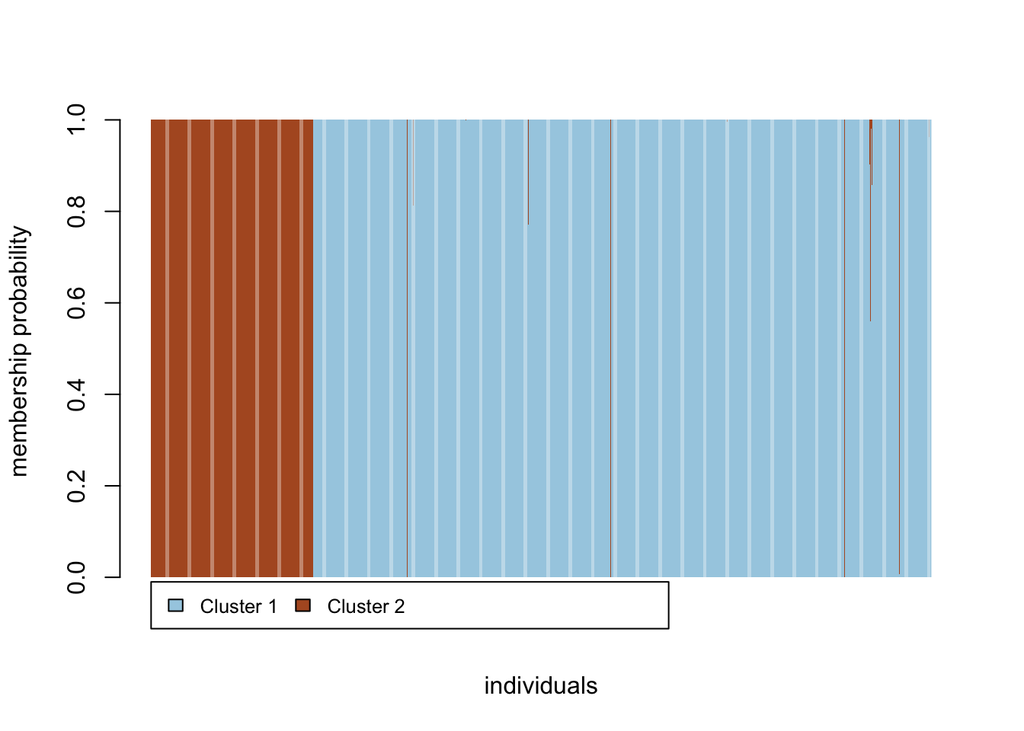

```r
compoplot(dapc1, txt.leg=paste("Cluster", 1:2), lab="", ncol=1, xlab="individuals")
```

```r
# Compare assignments
table(grp$grp, dapc1$assign)
```

```
##
##        1    2
##   1 1633    0
##   2   11  439
```

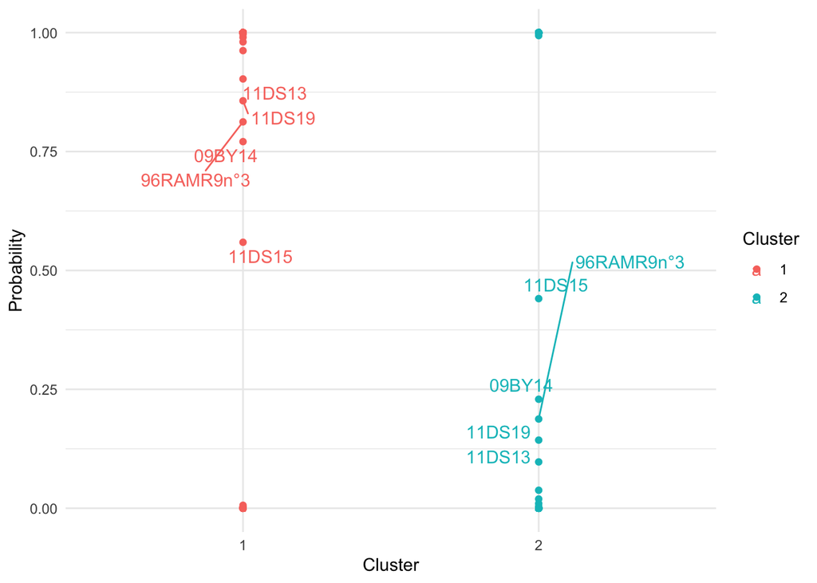

```r
#found special individual
# Convert the posterior probabilities to a data frame
posterior_data <- as.data.frame(dapc1$posterior)

# Add individual id as a column in the data frame
posterior_data$Individual <- rownames(posterior_data)

# Melt the data frame for visualization
melted_data <- reshape2::melt(posterior_data, id.vars = "Individual", variable.name = "Cluster", value.name = "Probability")

# Create a scatter plot with individual names as labels
#ggplot(melted_data, aes(x = Cluster, y = Probability, color = Cluster, label = Individual)) +
#  geom_point() +
#  xlab("Cluster") +
#  ylab("Probability") +
#  labs(color = "Cluster") +
#  theme_minimal() +
#  geom_text(nudge_y = 0.02)  # Add labels slightly above the data points

# Create a scatter plot with individual names as clear labels using ggrepel
ggplot(melted_data, aes(x = Cluster, y = Probability, color = Cluster, label = Individual)) +
  geom_point() +
  xlab("Cluster") +
  ylab("Probability") +
  labs(color = "Cluster") +
  theme_minimal() +
  geom_text_repel()  # Use geom_text_repel to avoid overlapping labels
```

```r
# Plot histograms
#ggplot(melted_data, aes(x = Probability)) +
#  geom_histogram(binwidth = 0.05) +
#  facet_wrap(~ Cluster, scales = "free_y") +
#  theme_minimal() +
#  labs(title = "Distribution of Posterior Probabilities", x = "Probability", y = "Frequency")


#reomve uncertin cluster
# Subset the main table to include only individuals with probability >= 0.8 in either cluster
certain_data <- genotype_mlp[posterior_data[, 1] >= 0.80 | posterior_data[, 2] >= 0.80 , ]


# Create a new table for uncertain individuals
uncertain_data <- genotype_mlp[posterior_data[, 1] < 0.80 & posterior_data[, 2] < 0.80, ]


genotype_data$Cluster <- ifelse(posterior_data[, 1] >= 0.80, "Cluster 1", #80%
                       ifelse(posterior_data[, 2] >= 0.80, "Cluster 2",
                                            "None Determined"))




# Inspect the assignments
table(genotype_data$Cluster)
```

```
##
##       Cluster 1       Cluster 2 None Determined
##            1642             439               2
```

```r
#Remove uncertain_data
genotype_data <- subset(genotype_data, Cluster %in% c("Cluster 1", "Cluster 2"))
```

### Calculation of population genetic indices for each cluster

Calcluation of the population genetic indices for each cluster, including the allelic richness (Ar), the observed heterozygosity (Ho), the expected heterozygosity (Hs), the inbreeding coefficient (Fis), and Linkage disequilibrium as rbarD value. The results are presented in a table format for easy comparison between the two clusters.

```r
# Creat it again because we removes uncertain data
# Select columns with "Mlp" in the name and the first column as isolate id
genotype_cols <- c(grep("Mlp", names(genotype_data), value = TRUE))
genotype_mlp <- genotype_data[, genotype_cols]

#make isolate id as column names
rownames(genotype_mlp) <- rownames(genotype_data)


# Convert to genind object
data_GenInd_Cluster <- df2genind(
  X = genotype_mlp,   #data.frame containing allele data only
  sep = NULL,
  ncode = 3,           #an optional integer giving the number of characters used for coding one genotype at one locus.
  ind.names = rownames(genotype_mlp),  # individuals names
  loc.names = colnames(genotype_mlp),  # markers names
  pop = genotype_data$Cluster,          # Define the population of each individual by it's cluster
  NA.char = "999",                      # string corresponding to missing allele 999 or 999999
  ploidy = 2,
  type = "codom",                       #codom' stands for 'codominant' (e.g. microstallites, allozymes)
  strata = NULL,
  hierarchy = NULL,
  check.ploidy = getOption("adegenet.check.ploidy")
)

Nb_Pop = length(levels(data_GenInd_Cluster@pop))

# Attribution des différents vecteurs que l'on souhaite calculer
N <- vector(mode ="integer", length = Nb_Pop)
GsurN<- vector(mode ="numeric", length = Nb_Pop)
Ho <- vector(mode ="numeric", length = Nb_Pop)
Hs <- vector(mode ="numeric", length = Nb_Pop)
Fis <- vector(mode ="numeric", length = Nb_Pop)
rbarD<- vector(mode ="numeric", length = Nb_Pop)

Pop <- levels(data_GenInd_Cluster$pop)

## Utilisation de Poppr pour récupérer les premiers indices N, G/N et rbarD
Table_PPR <- poppr(data_GenInd_Cluster) # marche bien

rbarD <- Table_PPR$rbarD[1:Nb_Pop]
N <- Table_PPR$N[1:Nb_Pop]
GsurN <- (Table_PPR$MLG[1:Nb_Pop]-1)/(Table_PPR$N[1:Nb_Pop]-1)

#calcul de la proba de DL
ProbaLD <- vector(mode ="numeric", length = Nb_Pop)
for (i in 1:Nb_Pop) {
  Temp_Sample <- popsub(data_GenInd_Cluster, Table_PPR$Pop[i])
  ProbaLD[i] = ia(Temp_Sample, sample = 999, plot = F)[4] # Attention c'est assez long à tourner
}


## Utilisation de Fstat pour calculer les autres indices HO, HE, Fis et Ar
data_Fstat <-genind2hierfstat(data_GenInd_Cluster)

# Boucles qui permet de calculer les indices souhaités pour chaque population (et pas la globalité)
a =0
for (i in levels(data_Fstat$pop) ){
  Poptmp <- data_GenInd_Cluster[which(data_GenInd_Cluster$pop==i),]
  #Poptmp  <-genind2hierfstat(Poptmp)
  fstat_basic_Temporel <- basic.stats(Poptmp)
  a = a+1
  Ho[a]<-fstat_basic_Temporel$overall["Ho"]
  Hs[a]<-fstat_basic_Temporel$overall["Hs"]
  Fis[a]<-fstat_basic_Temporel$overall["Fis"]
}

# calcul de la richess allélique
Obj_Ar <- allelic.richness(data_Fstat[which(data_Fstat[,"pop"]!="NA"),])
Ar_per_loc <- Obj_Ar$Ar
#Ar_per_loc <- Ar_per_loc[c(1:2, 4:13, 15:23),] # pour sortir les locus 100 et 26 qui sont absents de certaines pops
Ar<- vector(mode ="numeric", length = Nb_Pop)
for (i in 1:Nb_Pop){
  Ar[i] = mean(Ar_per_loc[,i])
}
##Beta_parato


## Mise en forme du tableau final
Tab_Indices_per_pop <- rbind(N, GsurN, Ar, Ho, Hs, Fis, rbarD)
colnames(Tab_Indices_per_pop) <- Pop
Tab_Indices_per_pop <- t(Tab_Indices_per_pop)
kable(Tab_Indices_per_pop, digits = 3)
```

|  | N | GsurN | Ar | Ho | Hs | Fis | rbarD |
| --- | --- | --- | --- | --- | --- | --- | --- |
| Cluster 2 | 439 | 0.142 | 4.371 | 0.524 | 0.358 | -0.463 | 0.359 |
| Cluster 1 | 1642 | 0.856 | 9.556 | 0.504 | 0.543 | 0.071 | 0.016 |

### Define the reproduction mode

Depending on the Fis value, we can assign the reproduction mode to each cluster. If the Fis value is negative, the cluster is assigned as asexual reproduction. If the Fis value is positive, the cluster is assigned as sexual reproduction. The results are stored in the “assignment” column of the genotype data table.

```r
# Tab_Indices_per_pop is the dataframe containing the results
# Loop through each row of the dataframe
# Define the  reproduction mode based on the Fis value (assignment)
for (i in 1:nrow(Tab_Indices_per_pop)) {
  cluster_name <- rownames(Tab_Indices_per_pop)[i]  # Get the cluster name

  # Check if the Fis value is negative
  if (Tab_Indices_per_pop[i, "Fis"] < 0) {
    # If Fis is negative, set the "Reproduction" column to "Asex" for the corresponding cluster
    genotype_data$assignment[genotype_data$Cluster == cluster_name] <- "Asex"
  } else {
    # If Fis is non-negative, set the "Reproduction" column to "Sex" for the corresponding cluster
    genotype_data$assignment[genotype_data$Cluster == cluster_name] <- "Sex"
  }
}
```

## Define the reproduction mode by biological approach

Depending on the MLL persistence, we can assign the reproduction mode to each lineage. If the same lineage exist at least two different years (avoiding clone mate) is asex, otherwise is sex. This done through two steps, first, we create a table of repeated MLLs in different years, then we assign the reproduction mode based on the MLL persistence. The results are stored in the “Mll_persistence” column of the genotype data table.

### Create table of repeated Mll diffrent years

```r
genotype_data$Year <- general_data$Year[match(row.names(genotype_data), general_data$Isolate)]

# Calculate the frequency of each MLL-Year combination
repeated_MLL_table <- genotype_data [,c("organised_MLL","Year")]
rownames(repeated_MLL_table) <- NULL
# Rename the columns for clarity
colnames(repeated_MLL_table) <- c("organised_MLL",  "Year")



# Create an empty list to store the dictionary
mll_year_dict <- list()

# Loop through each row in the repeated_MLL_table
for (i in 1:nrow(repeated_MLL_table)) {
  mll <- repeated_MLL_table$organised_MLL[i]
  Year <- repeated_MLL_table$Year[i]

  # If the MLL is not yet in the dictionary, add it with the current year
  if (!(mll %in% names(mll_year_dict))) {
    mll_year_dict[[as.character(mll)]] <- list(Year)
  } else {
    # If the MLL is already in the dictionary, append the year to its list
    mll_year_dict[[as.character(mll)]] <- c(mll_year_dict[[as.character(mll)]], Year)
  }
}


# Convert the dictionary to a dataframe
mll_year_df <- data.frame(
  organised_MLL = as.integer(names(mll_year_dict)),
  Years = sapply(mll_year_dict, paste, collapse = ", ")
)



# Create a new column to store the counts
mll_year_df$YearCount <- NA

# Loop through each row in repeated_MLL_table
for (i in 1:nrow(mll_year_df)) {
  # Filter the mll_year_df for the current MLL
  filtered_df <- mll_year_df[mll_year_df$organised_MLL == mll_year_df$organised_MLL[i], ]

  # Count how many years are associated with the current MLL
  years_count <- length(unlist(strsplit(filtered_df$Years, ", ")))

  # Assign the count to the YearCount column
  mll_year_df$YearCount[i] <- years_count
}

# Loop through each row in repeated_MLL_table
for (i in 1:nrow(repeated_MLL_table)) {
  # Filter the mll_year_df for the current MLL
  filtered_df <- mll_year_df[mll_year_df$organised_MLL == repeated_MLL_table$organised_MLL[i], ]

  # Get unique years associated with the current MLL
  unique_years <- unique(unlist(strsplit(filtered_df$Years, ", ")))

  # Combine unique years into a single string
  years_string <- paste(unique_years, collapse = ", ")

  # Assign the combined years to the Years column in mll_year_df
  mll_year_df[mll_year_df$organised_MLL == repeated_MLL_table$organised_MLL[i], "Years"] <- years_string
}

#remove all non repeated mll
mll_year_df <- mll_year_df[!(mll_year_df$YearCount == 1), ]

#test
#mll_year_df [mll_year_df$organised_MLL == 1, ]

# Print the contingency table
write.table(mll_year_df, file = "filtered_mll_years.csv", sep = ",", quote = FALSE, row.names = FALSE)
```

### Assign the reproduction mode based on the MLL persistence

```r
# the loop to define the Mll_persistence based on the number of years the MLL exist in the dataset, at least two years to be asex

for (i in 1:nrow(mll_year_df)) {
  if (mll_year_df$YearCount[i] >= 1) {
    mll <- mll_year_df[mll_year_df$organised_MLL == mll_year_df$organised_MLL[i], ]
    years_string <- mll$Years
    years <- unlist(strsplit(years_string, ", "))
    num_years <- length(unique(years))  # Count unique years

    if (num_years >= 2) { # If the MLL exists in at least two years, assign "Asex"
      mll_year_df$Mll_persistence[i] <- "Asex"
    } else {
      mll_year_df$Mll_persistence[i] <- "Sex"
    }
  } else {
    mll_year_df$Mll_persistence[i] <- "Sex"
  }
}


# the following loop to assign the Mll_persistence to the genotype data table

for (i in 1:nrow(mll_year_df)) {
  mll_value <- mll_year_df$organised_MLL[i]
  Mll_persistence_value <- mll_year_df$Mll_persistence[i]

  genotype_data$Mll_persistence[genotype_data$organised_MLL == mll_value] <- Mll_persistence_value
}

genotype_data[is.na(genotype_data$Mll_persistence), "Mll_persistence"] <- "Sex"
```

### Fisher’s exact test for the Mll_persistence and assignment

cross-tabulation of the assignment and Mll_persistence categories and perform a Fisher’s exact test to determine if there is a significant association between the two variables.

```
##
##        Asex  Sex
##   Asex  432    7
##   Sex    55 1587
```

```
##
##  Fisher's Exact Test for Count Data
##
## data:  contingency_table
## p-value < 2.2e-16
## alternative hypothesis: true odds ratio is not equal to 1
## 95 percent confidence interval:
##   782.942 4300.262
## sample estimates:
## odds ratio
##   1706.247
```

## Define reproduction mode based on both approches

If the individual is assigned to the Asex cluster or has Asex MLL persistence, assign “Asex” to the Reproduction column. Otherwise, assign “sex” to the Reproduction column.

```r
# Define the reproduction mode based on the assignment and Mll_persistence
#if it Asex either in assignment or Mll_persistence then it is Asex
genotype_data$Reproduction <- ifelse(genotype_data$assignment == "Asex" | genotype_data$Mll_persistence == "Asex", "Asex","Sex")
```

If the individual is assigned to the Asex cluster or has Asex MLL persistence, assign “Asex” to the Reproduction column, because it could be asexually reproducing but didn’t sampled so it is assigned as asex but not showed as asex in the MLL_persistence on the other hand if the individual is exist in the MLL_persistence but not assigned as asex then it is asexually reproducing biologically

## Population genetic indices for each reproduction mode

For sex and asex reproduction mode, we will calculate the population genetic indices for each mode separately. The results are presented in a table format for easy comparison between the two reproduction modes.

```r
# Convert to genind object
final_GenInd <- df2genind(
  X = genotype_mlp,   #data.frame containing allele data only
  sep = NULL,
  ncode = 3,           #an optional integer giving the number of characters used for coding one genotype at one locus.
  ind.names = rownames(genotype_mlp),  # individuals names
  loc.names = colnames(genotype_mlp),  # markers names
  pop = genotype_data$Reproduction,                       # giving the population of each individual
  NA.char = "999",                      # string corresponding to missing allele 999 or 999999
  ploidy = 2,
  type = "codom",                       #codom' stands for 'codominant' (e.g. microstallites, allozymes)
  strata = NULL,
  hierarchy = NULL,
  check.ploidy = getOption("adegenet.check.ploidy")
)


Nb_Pop = length(levels(final_GenInd@pop))

# Attribution des différents vecteurs que l'on souhaite calculer
N <- vector(mode ="integer", length = Nb_Pop)
GsurN<- vector(mode ="numeric", length = Nb_Pop)
Ho <- vector(mode ="numeric", length = Nb_Pop)
Hs <- vector(mode ="numeric", length = Nb_Pop)
Fis <- vector(mode ="numeric", length = Nb_Pop)
rbarD<- vector(mode ="numeric", length = Nb_Pop)
Fis_sd <- vector(mode ="numeric", length = Nb_Pop)

Pop <- levels(final_GenInd$pop)

## Utilisation de Poppr pour récupérer les premiers indices N, G/N et rbarD
Table_PPR <- poppr(final_GenInd) # marche bien

rbarD <- Table_PPR$rbarD[1:Nb_Pop]
N <- Table_PPR$N[1:Nb_Pop]
GsurN <- (Table_PPR$MLG[1:Nb_Pop]-1)/(Table_PPR$N[1:Nb_Pop]-1)

#calcul de la proba de DL
ProbaLD <- vector(mode ="numeric", length = Nb_Pop)
for (i in 1:Nb_Pop) {
  Temp_Sample <- popsub(final_GenInd, Table_PPR$Pop[i])
  ProbaLD[i] = ia(Temp_Sample, sample = 999, plot = F)[4] # Attention c'est assez long à tourner
}


## Utilisation de Fstat pour calculer les autres indices HO, HE, Fis et Ar

data_Fstat <-genind2hierfstat(final_GenInd)

# Boucles qui permet de calculer les indices souhaités pour chaque population (et pas la globalité)
a =0
for (i in levels(data_Fstat$pop) ){
  Poptmp <- final_GenInd[which(final_GenInd$pop==i),]
  #Poptmp  <-genind2hierfstat(Poptmp)
  fstat_basic_Temporel <- basic.stats(Poptmp)
  a = a+1
  Ho[a]<-fstat_basic_Temporel$overall["Ho"]
  Hs[a]<-fstat_basic_Temporel$overall["Hs"]
  Fis[a]<-fstat_basic_Temporel$overall["Fis"]
  Fis_sd[a]<- sd(fstat_basic_Temporel$perloc$Fis)
}

# calcul de la richess allélique
Obj_Ar <- allelic.richness(data_Fstat[which(data_Fstat[,"pop"]!="NA"),])
Ar_per_loc <- Obj_Ar$Ar
#Ar_per_loc <- Ar_per_loc[c(1:2, 4:13, 15:23),] # pour sortir les locus 100 et 26 qui sont absents de certaines pops
Ar<- vector(mode ="numeric", length = Nb_Pop)
for (i in 1:Nb_Pop){
  Ar[i] = mean(Ar_per_loc[,i])
}

## Mise en forme du tableau final
Tab_Indices_per_pop <- rbind(N, GsurN, Ar, Ho, Hs, Fis, rbarD,Fis_sd)
colnames(Tab_Indices_per_pop) <- Pop
Tab_Indices_per_pop <- t(Tab_Indices_per_pop)
kable(Tab_Indices_per_pop, digits = 3)
```

|  | N | GsurN | Ar | Ho | Hs | Fis | rbarD | Fis_sd |
| --- | --- | --- | --- | --- | --- | --- | --- | --- |
| Asex | 494 | 0.193 | 5.415 | 0.515 | 0.392 | -0.313 | 0.327 | 0.350 |
| Sex | 1587 | 0.865 | 9.787 | 0.506 | 0.544 | 0.068 | 0.012 | 0.066 |

[output not shown]

```r
#[1] 63
```

[output not shown]

```r
#[1] 1406
```

[output not shown]

```r
#[1] 58
```

[output not shown]

```r
#[1] 1400

#save the result
write.table(genotype_data, file = "new_genotype_data.csv", sep = ",", quote = FALSE, row.names = TRUE)

#clean
rm (Ar_per_loc, data_Fstat, fstat_basic_Temporel, Obj_Ar, Poptmp , Table_PPR, Temp_Sample)
```

## Population genetic indices for asex reproduction mode

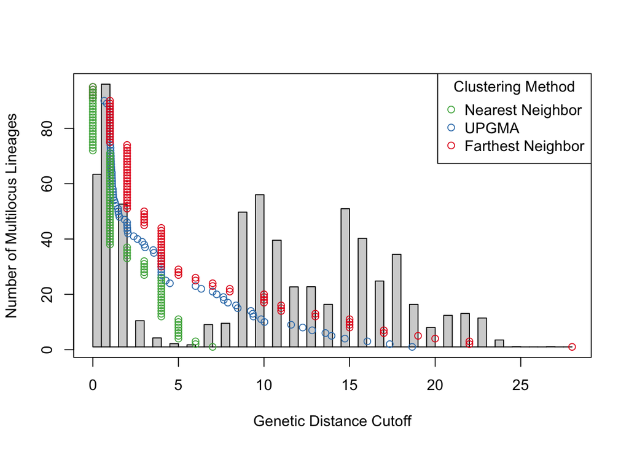

|  | N | GsurN | Ar | Ho | Hs | Fis | rbarD |
| --- | --- | --- | --- | --- | --- | --- | --- |
| 1 | 278 | 0.126 | 1.274 | 0.519 | 0.274 | -0.898 | -0.007 |
| 2 | 49 | 0.042 | 1.290 | 0.571 | 0.287 | -0.990 | 0.319 |
| 3 | 44 | 0.070 | 1.316 | 0.619 | 0.312 | -0.983 | -0.038 |
| 4 | 38 | 0.216 | 1.266 | 0.499 | 0.263 | -0.898 | 0.033 |
| 5 | 23 | 0.227 | 1.196 | 0.354 | 0.192 | -0.841 | 0.157 |
| 7 | 14 | 0.308 | 1.306 | 0.575 | 0.296 | -0.944 | -0.124 |
| 8 | 14 | 0.154 | 1.189 | 0.350 | 0.183 | -0.917 | -0.090 |
| 22 | 4 | 0.333 | 1.175 | 0.298 | 0.155 | -0.923 | NaN |
| 38 | 3 | 1.000 | 1.441 | 0.516 | 0.367 | -0.407 | 0.033 |
| 50 | 3 | 0.000 | 1.229 | 0.381 | 0.190 | -1.000 | NaN |

## Population genetic indices for sex reproduction mode

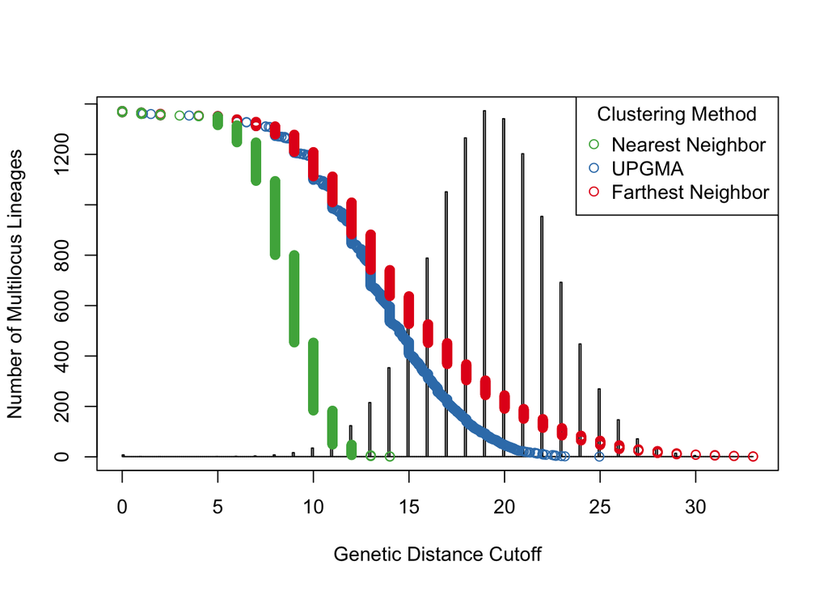

|  | N | GsurN | Ar | Ho | Hs | Fis | rbarD |
| --- | --- | --- | --- | --- | --- | --- | --- |
| 6 | 23 | 0.000 | 1.341 | 0.667 | 0.333 | -1.000 | NaN |
| 9 | 14 | 0.000 | 1.296 | 0.571 | 0.286 | -1.000 | NaN |
| 10 | 13 | 0.167 | 1.297 | 0.564 | 0.286 | -0.974 | -0.083 |
| 11 | 11 | 0.000 | 1.249 | 0.476 | 0.238 | -1.000 | NaN |
| 12 | 9 | 0.250 | 1.302 | 0.566 | 0.286 | -0.982 | NaN |
| 13 | 8 | 0.143 | 1.238 | 0.429 | 0.224 | -0.909 | NaN |
| 14 | 8 | 0.000 | 1.279 | 0.524 | 0.262 | -1.000 | NaN |
| 15 | 7 | 0.000 | 1.308 | 0.571 | 0.286 | -1.000 | NaN |
| 16 | 7 | 0.000 | 1.256 | 0.476 | 0.238 | -1.000 | NaN |
| 17 | 6 | 0.000 | 1.208 | 0.381 | 0.190 | -1.000 | NaN |

```r
#Add the region to the genotype data
genotype_data$Region <- general_data$Region[match(row.names(genotype_data), general_data$Isolate)]


# Convert to genind object
final_GenInd <- df2genind(
  X = genotype_mlp,   #data.frame containing allele data only
  sep = NULL,
  ncode = 3,           #an optional integer giving the number of characters used for coding one genotype at one locus.
  ind.names = rownames(genotype_mlp),  # individuals names
  loc.names = colnames(genotype_mlp),  # markers names
  pop = genotype_data$organised_MLL,                       # giving the population of each individual
  NA.char = "999",                      # string corresponding to missing allele 999 or 999999
  ploidy = 2,
  type = "codom",                       #codom' stands for 'codominant' (e.g. microstallites, allozymes)
  strata = NULL,
  hierarchy = NULL,
  check.ploidy = getOption("adegenet.check.ploidy")
)


# Calculate distance matrix and build NJ tree

dist <- diss.dist(final_GenInd) # Calculate the distance matrix
tree <- nj(dist) # Build the NJ tree
tree2 <- aboot(final_GenInd, dist = diss.dist , tree = "upgma", missing = "asis",sample= 1000) #1000
```

```
## Running bootstraps:       100 / 1000Running bootstraps:       200 / 1000Running bootstraps:       300 / 1000Running bootstraps:       400 / 1000Running bootstraps:       500 / 1000Running bootstraps:       600 / 1000Running bootstraps:       700 / 1000Running bootstraps:       800 / 1000Running b…
## Calculating bootstrap values... done.
```

[figure not shown]

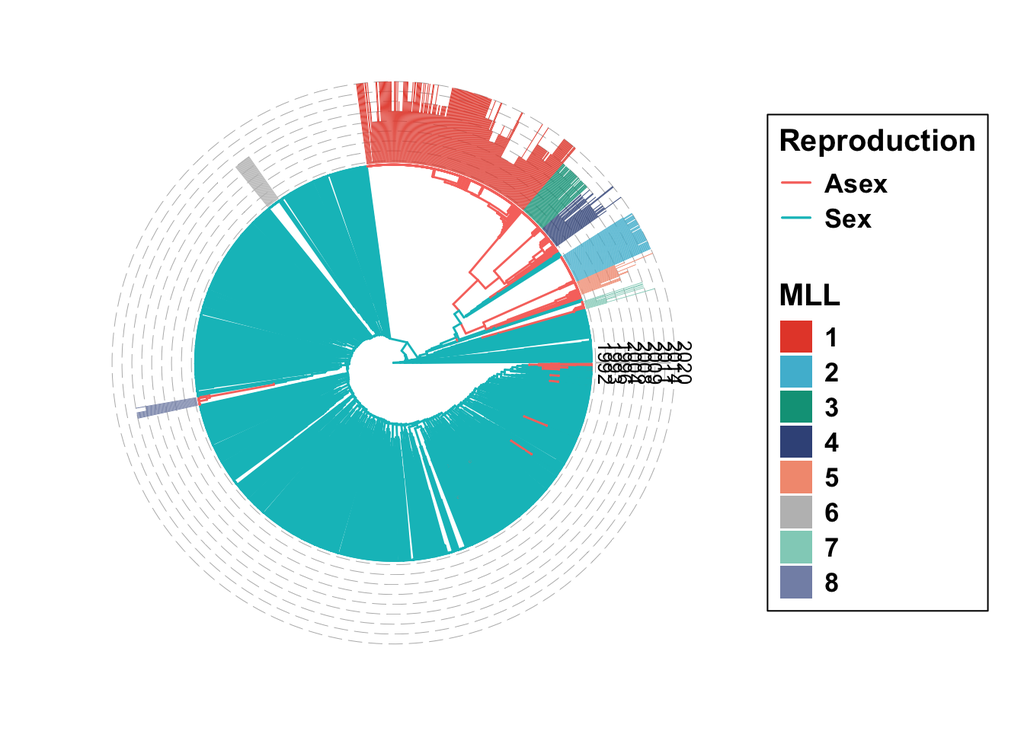

```r
# Create group information based on 'Reproduction' column, Sex and Asex
groupInfo <- split(rownames(genotype_data), genotype_data$Reproduction)

# Group the tree labels based on the group information
tree <- groupOTU(tree2, groupInfo)
npg_colors <- pal_npg("nrc")(8)  # Extract NPG colors, 8 colors for top 8 MLLs later


reproduction_colors <- c("Asex" = npg_colors[1], "Sex" = npg_colors[2])


p <- ggtree(tree, aes(color = group), layout = "circular") +
  scale_color_manual(values = reproduction_colors) +  # Apply the manual colors for 'Sex' and 'Asex'
  labs(color = "Reproduction") +  # Title for the color legend
  theme(
    panel.background = element_rect(fill = 'transparent'),  # Transparent panel background
    plot.background = element_rect(fill = 'transparent', color = NA),  # Transparent plot background
    panel.grid.major = element_blank(),  # Remove major gridlines
    panel.grid.minor = element_blank(),  # Remove minor gridlines
    legend.background = element_rect(fill = 'transparent'),  # Transparent legend background
    legend.box.background = element_rect(fill = 'transparent'),  # Transparent legend box
    legend.text = element_text(color = 'black', face = 'bold', size = 13),  # Legend text style
    legend.title = element_text(color = 'black', face = 'bold', size = 15)  # Legend title style
  )

# Display the tree plot
#p
# Create the ggtree plot with circular layout
options(ignore.negative.edge=TRUE)
p <- ggtree(tree, aes(color = group), layout="circular") +
  labs(color = "Reproduction") +
  # ... other plot customization here ...
  theme(
    panel.background = element_rect(fill='transparent'), # transparent panel bg
    plot.background = element_rect(fill='transparent', color=NA), # transparent plot bg
    panel.grid.major = element_blank(), # remove major gridlines
    panel.grid.minor = element_blank(), # remove minor gridlines
    legend.background = element_rect(fill='transparent'), # transparent legend bg
    legend.box.background = element_rect(fill='transparent'), # transparent legend panel
    legend.text = element_text(color = 'black', face = 'bold', size = 13), # set legend text color and size
    legend.title = element_text(color = 'black', face = 'bold', size = 15) # set legend title color and size

  )

#p

# Create a dataframe for annotation
dat1 <- data.frame(
  ID = rownames(genotype_data),
  MLL = genotype_data$organised_MLL,
  Group = genotype_data$Reproduction,
  Year = as.factor(genotype_data$Year),
  Location = genotype_data$Region

)
# Filter dat1 to include only MLL 1:17
dat1_filtered <- dat1[dat1$MLL %in% 1:8, ]
dat1_filtered$MLL <- as.factor(dat1_filtered$MLL)
dat1_filtered$Year <- as.character(dat1_filtered$Year)  # Convert to numeric if not already


# Manually define the color mapping
mll_color_mapping <- c(
  "1" = npg_colors[1],
  "2" = npg_colors[2],
  "3" = npg_colors[3],
  "4" = npg_colors[4],
  "5" = npg_colors[5],
  "6" = "grey",  # Set MLL 6 to grey, it's sexual lineage
  "8" = npg_colors[6],
  "7" = npg_colors[7],
  "8" = npg_colors[8]
)


# Convert MLL to factor
dat1_filtered$MLL <- as.factor(dat1_filtered$MLL)

# Use %<+% of ggtree to add annotation dataset to the tree
p1 <- p  %<+% dat1_filtered


# Initialize fill scale using new_scale_fill() from ggnewscale package
p2 <- p +
  geom_fruit(
    data = dat1_filtered,
    geom = geom_col,
    mapping = aes(y = ID, x = Year, fill = MLL),  # Map 'Location' to fill
    pwidth = 0.4,
    offset = 0.01,
    axis.params = list(
      axis = "x",  # Add x-axis text
      text.angle = -90,  # Adjust text angle
      text.size = 3.4,
      vjust = -0.2,
      line.alpha = 0,
    ),
    grid.params = list(color = "black", linetype = 5, size = 0.1, alpha = 0.6)  # Add grid lines
  ) +
  scale_fill_manual(values = mll_color_mapping) +
   # Customize the color gradient
  theme(
    panel.background = element_rect(fill='transparent'), # transparent panel bg
    plot.background = element_rect(fill='transparent', color=NA), # transparent plot bg
    panel.grid.major = element_blank(), # remove major gridlines
    panel.grid.minor = element_blank(), # remove minor gridlines
    legend.background = element_rect(fill='transparent'), # transparent legend bg
    legend.box.background = element_rect(fill='transparent'), # transparent legend panel
    legend.text = element_text(color = 'black', face = 'bold', size = 13), # set legend text color and size
    legend.title = element_text(color = 'black', face = 'bold', size = 15) # set legend title color and size

  )

# Modify legend titles
p2 <- p2 +
  labs(fill = "MLL", color = "Reproduction")

p2
```

```r
ggsave("tree_plot1.png", p, width = 17, height = 8, dpi = 600, bg = "transparent")  # Save the plot with desired dimensions

ggsave("tree_plot2.png", p2, width = 17, height = 8, dpi = 600, bg = "transparent")  # Save the plot with desired dimensions
```

## Spatial analysis

### Geographical distribution of mlp across France 2009 and 2011

```r
pop_data <- genotype_data %>%
  filter(Year == c("2009","2011")) %>%
  group_by(Pop, Long, Lat, Reproduction) %>%
  summarize(n = n(), .groups = "drop") %>%   # Specify .groups = "drop" to remove grouping
  mutate(percent = n / sum(n)) %>%
  select(Pop, Long, Lat, Reproduction, n, percent)
```

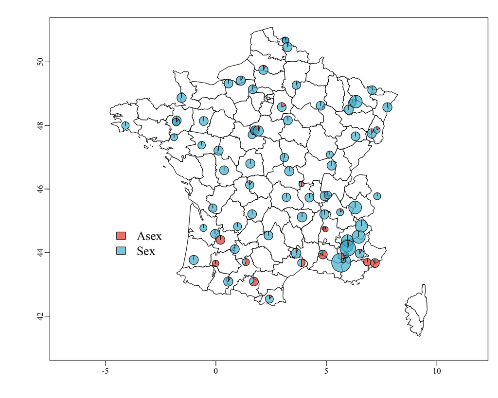

```r
#draw map Representative the popular individual across France map within reproductive mode
# The area of the France Region;
xlim <- c(-4.3,9.1)
ylim <- c(41, 51)

# Creates an xyz object for use with the function draw.pie
xyz <- make.xyz(pop_data$Long, pop_data$Lat, pop_data$percent, pop_data$Reproduction)


# Create a named vector to map profiles to colors
#profile_color_mapping <- setNames(my_colors, unique_profiles)

# Create a named vector for profile colors
profile_color_mapping <- c("Asex" = npg_colors[1], "Sex" = npg_colors[2])
transparent_colors <- adjustcolor(profile_color_mapping, alpha.f = 0.7)


# The plot of the pie chart above the map
#png(filename = "map_2009_2011_output.png", width = 1000, height = 800, bg = "transparent")

par(mai = c(0.5, 0.5, 0.35, 0.2), omi = c(0.25, 0.5, 0, 0),
    mgp = c(2.5, 0.5, 0), family = "Times New Roman",col = "black")
basemap(xlim = c(-4.3, 9.1), ylim = c(41, 51), bg = "transparent",
        col.main="white", cex.main = 1.6)
map("france", fill = FALSE, col = "black", xlim = xlim, ylim = ylim, add = TRUE)
final_map <- draw.pie(xyz$x, xyz$y, xyz$z, radius = 0.3, col = transparent_colors)

legend(-5, 45, legend = c("Asex", "Sex"), fill = transparent_colors, bty = "n", cex = 1.5, ncol = 1, text.col = "black")
```

```r
#view the map

#dev.off()
```

## Regression analysis

Reproduction mode with latitude, longitude, and year (all years)

```
##
## Call:
## glm(formula = cbind(nbsex, nbAsex) ~ Lat + Long + Year, family = binomial,
##     data = final_table)
##
## Coefficients:
##               Estimate Std. Error z value Pr(>|z|)
## (Intercept)  -37.65407 3956.18109  -0.010  0.99241
## Lat            0.44726    0.04673   9.571  < 2e-16 ***
## Long           0.09529    0.02904   3.281  0.00103 **
## Year1993      17.78461 3956.18074   0.004  0.99641
## Year1994      34.61042 4520.08100   0.008  0.99389
## Year1996      -1.51129 4411.37362   0.000  0.99973
## Year1998      32.95350 4687.85634   0.007  0.99439
## Year2004      -1.18200 4173.20920   0.000  0.99977
## Year2008      13.57456 3956.18067   0.003  0.99726
## Year2009      18.40374 3956.18054   0.005  0.99629
## Year2011      19.14842 3956.18054   0.005  0.99614
## Year2014      -1.20040 4822.70694   0.000  0.99980
## Year2020      -1.75579 4007.42319   0.000  0.99965
## ---
## Signif. codes:  0 '***' 0.001 '**' 0.01 '*' 0.05 '.' 0.1 ' ' 1
##
## (Dispersion parameter for binomial family taken to be 1)
##
##     Null deviance: 1737.74  on 117  degrees of freedom
## Residual deviance:  677.15  on 105  degrees of freedom
## AIC: 801.64
##
## Number of Fisher Scoring iterations: 16
```

```
## Generalized linear mixed model fit by maximum likelihood (Laplace
##   Approximation) [glmerMod]
##  Family: binomial  ( logit )
## Formula: cbind(nbsex, nbAsex) ~ Lat + Long + (1 | Year)
##    Data: final_table
##
##      AIC      BIC   logLik deviance df.resid
##    820.2    831.3   -406.1    812.2      114
##
## Scaled residuals:
##      Min       1Q   Median       3Q      Max
## -10.5465  -0.3746   0.2013   1.2474   5.3348
##
## Random effects:
##  Groups Name        Variance Std.Dev.
##  Year   (Intercept) 21.18    4.602
## Number of obs: 118, groups:  Year, 11
##
## Fixed effects:
##              Estimate Std. Error z value Pr(>|z|)
## (Intercept) -23.32225    2.83077  -8.239  < 2e-16 ***
## Lat           0.45236    0.04687   9.651  < 2e-16 ***
## Long          0.09483    0.02907   3.262  0.00111 **
## ---
## Signif. codes:  0 '***' 0.001 '**' 0.01 '*' 0.05 '.' 0.1 ' ' 1
##
## Correlation of Fixed Effects:
##      (Intr) Lat
## Lat  -0.742
## Long -0.207  0.204
```

### Plot the regression

```
##
## Call:
## glm(formula = cbind(nbsex, nbAsex) ~ Lat + Long + Year, family = binomial,
##     data = final_table_filtered)
##
## Coefficients:
##              Estimate Std. Error z value Pr(>|z|)
## (Intercept) -19.08392    2.12559  -8.978  < 2e-16 ***
## Lat           0.44359    0.04671   9.497  < 2e-16 ***
## Long          0.09486    0.02903   3.267  0.00109 **
## Year2011      0.74503    0.16068   4.637 3.54e-06 ***
## ---
## Signif. codes:  0 '***' 0.001 '**' 0.01 '*' 0.05 '.' 0.1 ' ' 1
##
## (Dispersion parameter for binomial family taken to be 1)
##
##     Null deviance: 809.51  on 82  degrees of freedom
## Residual deviance: 665.20  on 79  degrees of freedom
## AIC: 771.7
##
## Number of Fisher Scoring iterations: 5
```

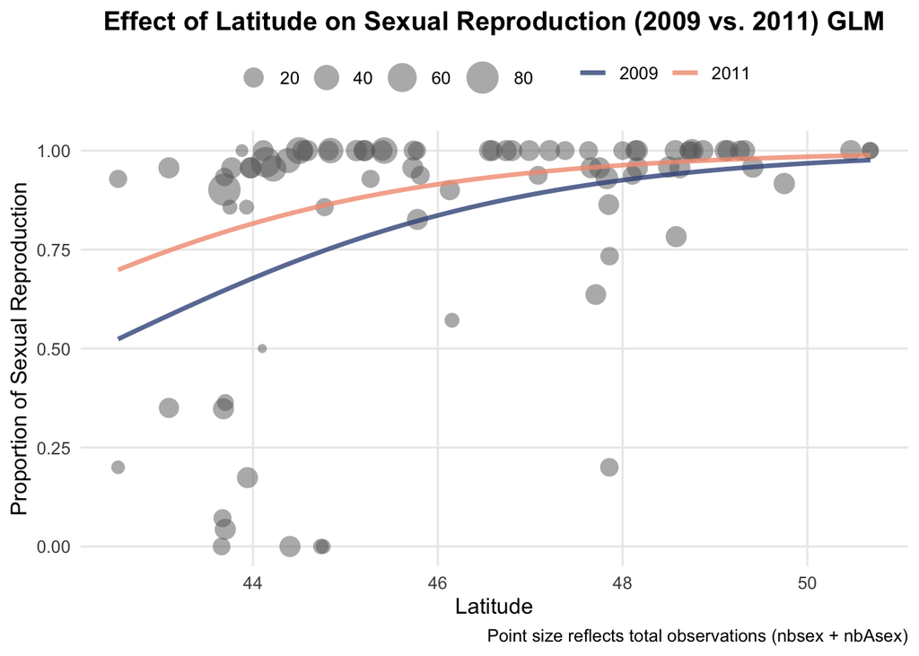

```
## Generalized linear mixed model fit by maximum likelihood (Laplace
##   Approximation) [glmerMod]
##  Family: binomial  ( logit )
## Formula: cbind(nbsex, nbAsex) ~ Lat + Long + (1 | Year)
##    Data: final_table_filtered
##
##      AIC      BIC   logLik deviance df.resid
##    778.6    788.3   -385.3    770.6       79
##
## Scaled residuals:
##      Min       1Q   Median       3Q      Max
## -10.4325  -0.5677   0.8002   1.4943   4.1960
##
## Random effects:
##  Groups Name        Variance Std.Dev.
##  Year   (Intercept) 0.1246   0.353
## Number of obs: 83, groups:  Year, 2
##
## Fixed effects:
##              Estimate Std. Error z value Pr(>|z|)
## (Intercept) -18.73319    2.13586  -8.771  < 2e-16 ***
## Lat           0.44460    0.04666   9.528  < 2e-16 ***
## Long          0.09202    0.02906   3.166  0.00154 **
## ---
## Signif. codes:  0 '***' 0.001 '**' 0.01 '*' 0.05 '.' 0.1 ' ' 1
##
## Correlation of Fixed Effects:
##      (Intr) Lat
## Lat  -0.991
## Long -0.249  0.202
```

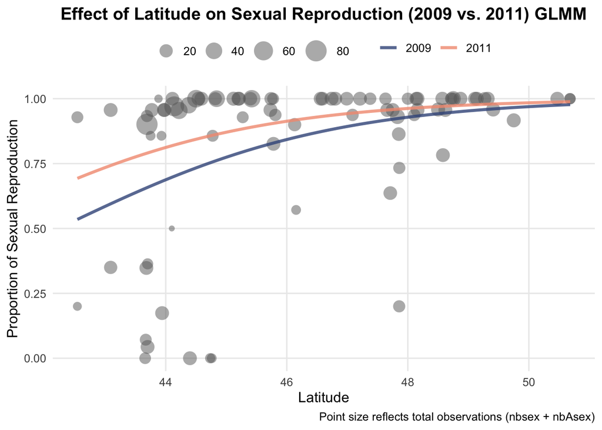

## Creat data for ClonEstiMate

```r
# Create table for minimum spanning tree (MST) software by selecting relevant columns
MST_data <- c("Pop", "Year", "Isolate", grep("Mlp", names(general_data), value = TRUE))
MST_data <- general_data[, MST_data]

# Rename the second and third columns
colnames(MST_data)[2:3] <- c("gen", "tag")

# Function to split six-digit numbers into two columns
split_alleles <- function(x) {
  a <- as.numeric(substr(x, 1, 3))
  b <- as.numeric(substr(x, 4, 6))
  return(data.frame(a, b))
}

# Apply the split function to each Mlp_ column
split_columns <- lapply(MST_data[, -c(1:3)], split_alleles)

# Combine all split columns into a single data frame
split_data <- do.call(cbind, split_columns)

# Remove the column names of each second column in the split allele pairs
num_cols <- ncol(split_data)
for (i in seq(2, num_cols, by = 2)) {
  colnames(split_data)[i] <- ""
}


# Generate the 'ID' column as a unique identifier like 'C1', 'C2', 'C3', etc.
MST_data$ID <- paste0("C", seq_len(nrow(MST_data)))


# Create a new data frame with the desired format
MST_data <- data.frame(
  Pop = MST_data$Pop,
  gen = MST_data$gen,
  ID = MST_data$ID,
  tag = MST_data$tag,  # assuming tag is the same as ID
  color = "Red",  # assuming 'Red' is the color for all
  Ploidy = 2,  # assuming ploidy is 2
  split_data
)


# Delete second col name for each allele
colnames(MST_data)[grep("Var", colnames(MST_data))] <- ""



# Read the CSV file and set the first column as row names
new_genotype_data <- read.csv("new_genotype_data.csv", row.names = 1)


# Check the Reproduction status in new_genotype_data and update the color in MST_data
for (i in seq_len(nrow(MST_data))) {
  tag_name <- MST_data$tag[i]

  # Check if the tag_name exists in the row names of new_genotype_data
  if (tag_name %in% rownames(new_genotype_data)) {
    reproduction_status <- new_genotype_data[tag_name, "Reproduction"]

    # Update the color based on the Reproduction status
    if (reproduction_status == "Sex") {
      MST_data$color[i] <- "Blue"
    } else if (reproduction_status == "Asex") {
      MST_data$color[i] <- "Red"
    }
  }
}


# View the final MST data
head(MST_data)
```

```
##    Pop  gen ID    tag color Ploidy Mlp_91.a     Mlp_83.a     Mlp_50.a
## 1 14AA 2014 C1 14AA01   Red      2      128 131      157 157      277 283
## 2 14AA 2014 C2 14AA04   Red      2      128 131      157 157      277 280
## 3 14AA 2014 C3 14AA02   Red      2      128 128      148 157      280 283
## 4 14AA 2014 C4 14AA05   Red      2      128 128      148 157      280 283
## 5 14AA 2014 C5 14AA06   Red      2      128 128      148 157      280 283
## 6 14AA 2014 C6 14AA10   Red      2      128 128      148 157      280 283
##   Mlp_71.a     Mlp_96.a     Mlp_95.a     Mlp_55.a     Mlp_66.a     Mlp_12.a
## 1      364 368      410 410      453 453      152 152      195 198      244 244
## 2      368 368      404 410      453 453      152 152      189 198      244 265
## 3      368 368      404 410      453 453      152 155      192 195      226 247
## 4      368 368      404 410      453 453      152 155      192 195      226 247
## 5      368 368      404 410      453 453      152 155      192 195      226 247
## 6      368 368      404 410      453 453      152 155      192 195      226 247
##   Mlp_68b.a     Mlp_54.a     Mlp_57.a     Mlp_58.a     Mlp_49.a     Mlp_93.a
```

[output cut: 20 more lines]

```r
# Think I need to keep only 2009 2011 data

write.table(MST_data, "MST_data_mlp.txt", sep = "\t",quote = FALSE, row.names = FALSE, col.names =TRUE)
```